# SIR - введение в базовое R

Grigory Gladkov

2023-01-16

## импорт

```r
library(readxl)
library(tidyverse)
```

## Горячие клавиши:

- `Ctrl + Shift + C` - закомментировать/раскомментировать
- `Ctrl + Enter` - выполнить активную строку
- `Tab` или `Ctrl + Space` - автоподстановка
- `Alt + -` - присвоение
- `Ctr + Shift + M` - pipe
- Встроенная справка ?названиеФункции

# День 1

## Задать рабочее окружение

```r
setwd('~/Documents/SIR_wd/')
getwd()
```

```
## [1] "/home/crabron/Documents/SIR_wd"
```

```r
list.files()
```

```
##  [1] "dadaRs"            "dadaRs.RDS"        "databases"
##  [4] "errF.RDS"          "errR.RDS"          "map.csv"
##  [7] "pen_ans_var.R"     "pen_wd.R"          "pen.csv"
## [10] "pen.html"          "pen.nb.html"       "pen.R"
## [13] "pen.Rmd"           "pen.xlsx"          "raw"
## [16] "taxa.RDS"          "test_dada.nb.html" "test_dada.Rmd"
```

чтение файла(csv - comma delimited - разделитель запятая)

```r
pen <- read.csv('pen.csv', row.names = 'X')
```

## Cвойства таблицы

класс объекта

```r
class(pen)
```

```
## [1] "data.frame"
```

количество строк

```r
nrow(pen)
```

```
## [1] 344
```

количество столбцов

```r
ncol(pen)
```

```
## [1] 8
```

типы столбцов

```r
str(pen)
```

```
## 'data.frame':    344 obs. of  8 variables:
##  $ species          : chr  "Adelie" "Adelie" "Adelie" "Adelie" ...
##  $ island           : chr  "Torgersen" "Torgersen" "Torgersen" "Torgersen" ...
##  $ bill_length_mm   : num  39.1 39.5 40.3 NA 36.7 39.3 38.9 39.2 34.1 42 ...
##  $ bill_depth_mm    : num  18.7 17.4 18 NA 19.3 20.6 17.8 19.6 18.1 20.2 ...
##  $ flipper_length_mm: int  181 186 195 NA 193 190 181 195 193 190 ...
##  $ body_mass_g      : int  3750 3800 3250 NA 3450 3650 3625 4675 3475 4250 ...
##  $ sex              : chr  "male" "female" "female" NA ...
##  $ year             : int  2007 2007 2007 2007 2007 2007 2007 2007 2007 2007 ...
```

проверить на наличие NA и удалить их

```r
colSums(is.na(pen))
```

```
##           species            island    bill_length_mm     bill_depth_mm
##                 0                 0                 2                 2
## flipper_length_mm       body_mass_g               sex              year
##                 2                 2                11                 0
```

```r
pen.no.na <- na.omit(pen)
```

## Индексация

столбцы  
`%>% head()` вставлено для удобства вывода

```r
pen.no.na[,2] %>%
  head()
```

```
## [1] "Torgersen" "Torgersen" "Torgersen" "Torgersen" "Torgersen" "Torgersen"
```

```r
pen.no.na[,'island'] %>%
  head()
```

```
## [1] "Torgersen" "Torgersen" "Torgersen" "Torgersen" "Torgersen" "Torgersen"
```

строки

```r
pen.no.na[2,]
```

```
##       species    island bill_length_mm bill_depth_mm flipper_length_mm
## pen_2  Adelie Torgersen           39.5          17.4               186
##       body_mass_g    sex year
## pen_2        3800 female 2007
```

```r
pen.no.na[c('pen_1', 'pen_3'),]
```

```
##       species    island bill_length_mm bill_depth_mm flipper_length_mm
## pen_1  Adelie Torgersen           39.1          18.7               181
## pen_3  Adelie Torgersen           40.3          18.0               195
##       body_mass_g    sex year
## pen_1        3750   male 2007
## pen_3        3250 female 2007
```

ячейка

```r
pen.no.na[13,5]
```

```
## [1] 197
```

фильтрация  
Только те строки где пингвины - Адели  
`%>% head()` вставлено для удобства вывода

```r
head(pen.no.na[pen.no.na$species  == 'Adelie',]) %>%
  head()
```

```
##       species    island bill_length_mm bill_depth_mm flipper_length_mm
## pen_1  Adelie Torgersen           39.1          18.7               181
## pen_2  Adelie Torgersen           39.5          17.4               186
## pen_3  Adelie Torgersen           40.3          18.0               195
## pen_5  Adelie Torgersen           36.7          19.3               193
## pen_6  Adelie Torgersen           39.3          20.6               190
## pen_7  Adelie Torgersen           38.9          17.8               181
##       body_mass_g    sex year
## pen_1        3750   male 2007
## pen_2        3800 female 2007
## pen_3        3250 female 2007
## pen_5        3450 female 2007
## pen_6        3650   male 2007
## pen_7        3625 female 2007
```

# День 2

## Логические операторы

Только те строки где пингвины - Адели и самцы

```r
pen.no.na[pen.no.na$species  == 'Adelie' & pen.no.na$sex  == 'male',] %>%
  head()
```

```
##        species    island bill_length_mm bill_depth_mm flipper_length_mm
## pen_1   Adelie Torgersen           39.1          18.7               181
## pen_6   Adelie Torgersen           39.3          20.6               190
## pen_8   Adelie Torgersen           39.2          19.6               195
## pen_14  Adelie Torgersen           38.6          21.2               191
## pen_15  Adelie Torgersen           34.6          21.1               198
## pen_18  Adelie Torgersen           42.5          20.7               197
##        body_mass_g  sex year
## pen_1         3750 male 2007
## pen_6         3650 male 2007
## pen_8         4675 male 2007
## pen_14        3800 male 2007
## pen_15        4400 male 2007
## pen_18        4500 male 2007
```

еще примеры фильтрации

```r
pen.no.na[pen.no.na$body_mass_g > 3200,] %>%
  head()
```

```
##       species    island bill_length_mm bill_depth_mm flipper_length_mm
## pen_1  Adelie Torgersen           39.1          18.7               181
## pen_2  Adelie Torgersen           39.5          17.4               186
## pen_3  Adelie Torgersen           40.3          18.0               195
## pen_5  Adelie Torgersen           36.7          19.3               193
## pen_6  Adelie Torgersen           39.3          20.6               190
## pen_7  Adelie Torgersen           38.9          17.8               181
##       body_mass_g    sex year
## pen_1        3750   male 2007
## pen_2        3800 female 2007
## pen_3        3250 female 2007
## pen_5        3450 female 2007
## pen_6        3650   male 2007
## pen_7        3625 female 2007
```

```r
pen.no.na[pen.no.na$body_mass_g > 3200 | pen.no.na$bill_length_mm > 200, ] %>%
  head()
```

```
##       species    island bill_length_mm bill_depth_mm flipper_length_mm
## pen_1  Adelie Torgersen           39.1          18.7               181
## pen_2  Adelie Torgersen           39.5          17.4               186
## pen_3  Adelie Torgersen           40.3          18.0               195
## pen_5  Adelie Torgersen           36.7          19.3               193
## pen_6  Adelie Torgersen           39.3          20.6               190
## pen_7  Adelie Torgersen           38.9          17.8               181
##       body_mass_g    sex year
## pen_1        3750   male 2007
## pen_2        3800 female 2007
## pen_3        3250 female 2007
## pen_5        3450 female 2007
## pen_6        3650   male 2007
## pen_7        3625 female 2007
```

## Циклы и списки

код учебный - это неэффективный путь

Создаём список из массы тела

```r
mass.list <-  as.list(pen.no.na$body_mass_g)
mass.list %>%
  head()
```

```
## [[1]]
## [1] 3750
##
## [[2]]
## [1] 3800
##
## [[3]]
## [1] 3250
##
## [[4]]
## [1] 3450
##
## [[5]]
## [1] 3650
##
## [[6]]
## [1] 3625
```

```r
pood.mass <- list()

for (i in mass.list){
  res <- i / 16.3807
  pood.mass <- append(pood.mass, res)
}

unlist(pood.mass)
```

```
##   [1] 228.9279 231.9803 198.4042 210.6137 222.8232 221.2970 285.3968 195.3518
##   [9] 231.9803 268.6088 225.8756 210.6137 274.7135 202.9828 256.3993 207.5613
##  [17] 219.7708 231.9803 241.1374 231.9803 231.9803 216.7185 195.3518 192.2995
##  [25] 241.1374 198.4042 238.0851 201.4566 238.0851 202.9828 253.3469 241.1374
##  [33] 216.7185 201.4566 283.8707 192.2995 238.0851 189.2471 268.6088 183.1424
##  [41] 280.8183 209.0875 210.6137 253.3469 213.6661 262.5040 210.6137 247.2422
##  [49] 177.0376 225.8756 216.7185 231.9803 173.9852 228.9279 192.2995 268.6088
##  [57] 219.7708 247.2422 173.9852 241.1374 204.5090 250.2946 186.1947 271.6612
##  [65] 219.7708 238.0851 216.7185 253.3469 225.8756 259.4517 225.8756 238.0851
##  [73] 216.7185 244.1898 195.3518 286.9230 231.9803 256.3993 204.5090 216.7185
##  [81] 231.9803 213.6661 241.1374 219.7708 216.7185 262.5040 207.5613 271.6612
##  [89] 201.4566 262.5040 225.8756 265.5564 177.0376 250.2946 227.4018 288.4492
##  [97] 187.7209 259.4517 178.5638 216.7185 228.9279 238.0851 193.8257 291.5016
## [105] 233.5065 280.8183 195.3518 260.9779 238.0851 248.7684 177.0376 230.4541
## [113] 204.5090 202.9828 192.2995 213.6661 210.6137 236.5589 186.1947 244.1898
```

[output cut: 27 more lines]

можно было проще

```r
pen.no.na$body_mass_g / 16.3807
```

```
##   [1] 228.9279 231.9803 198.4042 210.6137 222.8232 221.2970 285.3968 195.3518
##   [9] 231.9803 268.6088 225.8756 210.6137 274.7135 202.9828 256.3993 207.5613
##  [17] 219.7708 231.9803 241.1374 231.9803 231.9803 216.7185 195.3518 192.2995
##  [25] 241.1374 198.4042 238.0851 201.4566 238.0851 202.9828 253.3469 241.1374
##  [33] 216.7185 201.4566 283.8707 192.2995 238.0851 189.2471 268.6088 183.1424
##  [41] 280.8183 209.0875 210.6137 253.3469 213.6661 262.5040 210.6137 247.2422
##  [49] 177.0376 225.8756 216.7185 231.9803 173.9852 228.9279 192.2995 268.6088
##  [57] 219.7708 247.2422 173.9852 241.1374 204.5090 250.2946 186.1947 271.6612
##  [65] 219.7708 238.0851 216.7185 253.3469 225.8756 259.4517 225.8756 238.0851
##  [73] 216.7185 244.1898 195.3518 286.9230 231.9803 256.3993 204.5090 216.7185
##  [81] 231.9803 213.6661 241.1374 219.7708 216.7185 262.5040 207.5613 271.6612
##  [89] 201.4566 262.5040 225.8756 265.5564 177.0376 250.2946 227.4018 288.4492
##  [97] 187.7209 259.4517 178.5638 216.7185 228.9279 238.0851 193.8257 291.5016
## [105] 233.5065 280.8183 195.3518 260.9779 238.0851 248.7684 177.0376 230.4541
## [113] 204.5090 202.9828 192.2995 213.6661 210.6137 236.5589 186.1947 244.1898
```

[output cut: 27 more lines]

## Семейство apply

Лучше итерироваться семейством функций apply.

```r
apply(pen.no.na[,3:6], 2,  mean)
```

```
##    bill_length_mm     bill_depth_mm flipper_length_mm       body_mass_g
##          43.99279          17.16486         200.96697        4207.05706
```

```r
colMeans(pen.no.na[,3:6])
```

```
##    bill_length_mm     bill_depth_mm flipper_length_mm       body_mass_g
##          43.99279          17.16486         200.96697        4207.05706
```

```r
apply(pen.no.na[,3:6], 2,  median)
```

```
##    bill_length_mm     bill_depth_mm flipper_length_mm       body_mass_g
##              44.5              17.3             197.0            4050.0
```

## Пользовательские функции

```r
pood_transformer <- function(value){
  pood <- 16.3807
  res <- value / pood
  res
}

sapply(pen.no.na$body_mass_g, pood_transformer)
```

```
##   [1] 228.9279 231.9803 198.4042 210.6137 222.8232 221.2970 285.3968 195.3518
##   [9] 231.9803 268.6088 225.8756 210.6137 274.7135 202.9828 256.3993 207.5613
##  [17] 219.7708 231.9803 241.1374 231.9803 231.9803 216.7185 195.3518 192.2995
##  [25] 241.1374 198.4042 238.0851 201.4566 238.0851 202.9828 253.3469 241.1374
##  [33] 216.7185 201.4566 283.8707 192.2995 238.0851 189.2471 268.6088 183.1424
##  [41] 280.8183 209.0875 210.6137 253.3469 213.6661 262.5040 210.6137 247.2422
##  [49] 177.0376 225.8756 216.7185 231.9803 173.9852 228.9279 192.2995 268.6088
##  [57] 219.7708 247.2422 173.9852 241.1374 204.5090 250.2946 186.1947 271.6612
##  [65] 219.7708 238.0851 216.7185 253.3469 225.8756 259.4517 225.8756 238.0851
##  [73] 216.7185 244.1898 195.3518 286.9230 231.9803 256.3993 204.5090 216.7185
##  [81] 231.9803 213.6661 241.1374 219.7708 216.7185 262.5040 207.5613 271.6612
##  [89] 201.4566 262.5040 225.8756 265.5564 177.0376 250.2946 227.4018 288.4492
##  [97] 187.7209 259.4517 178.5638 216.7185 228.9279 238.0851 193.8257 291.5016
## [105] 233.5065 280.8183 195.3518 260.9779 238.0851 248.7684 177.0376 230.4541
## [113] 204.5090 202.9828 192.2995 213.6661 210.6137 236.5589 186.1947 244.1898
```

[output cut: 27 more lines]

## Tidyverse

pipe - `Ctr + Shift + M`

```r
pen.ex <- read_xlsx('pen.xlsx')
# pen.ex <- readxl::read_xlsx('pen.xlsx')
pen.ex
```

```
## # A tibble: 344 × 8
##    species island    bill_length_mm bill_depth_mm flipper_length_mm body_mass_g
##    <chr>   <chr>              <dbl>         <dbl>             <dbl>       <dbl>
##  1 Adelie  Torgersen           39.1          18.7               181        3750
##  2 Adelie  Torgersen           39.5          17.4               186        3800
##  3 Adelie  Torgersen           40.3          18                 195        3250
##  4 Adelie  Torgersen           NA            NA                  NA          NA
##  5 Adelie  Torgersen           36.7          19.3               193        3450
##  6 Adelie  Torgersen           39.3          20.6               190        3650
##  7 Adelie  Torgersen           38.9          17.8               181        3625
##  8 Adelie  Torgersen           39.2          19.6               195        4675
##  9 Adelie  Torgersen           34.1          18.1               193        3475
## 10 Adelie  Torgersen           42            20.2               190        4250
## # ℹ 334 more rows
## # ℹ 2 more variables: sex <chr>, year <dbl>
```

pen.no.na[,‘island’]

```r
pen.ex %>%
  select(island) %>%
  head()
```

```
## # A tibble: 6 × 1
##   island
##   <chr>
## 1 Torgersen
## 2 Torgersen
## 3 Torgersen
## 4 Torgersen
## 5 Torgersen
## 6 Torgersen
```

pen.no.na <- na.omit(pen)

```r
pen.ex.na <- pen.ex %>%
  drop_na()
```

pen.no.na[pen.no.na$species == 'Adelie' & pen.no.na$sex == ‘male’,]

```r
pen.ex.na %>%
  filter(species == 'Adelie' & sex == 'male')
```

```
## # A tibble: 73 × 8
##    species island    bill_length_mm bill_depth_mm flipper_length_mm body_mass_g
##    <chr>   <chr>              <dbl>         <dbl>             <dbl>       <dbl>
##  1 Adelie  Torgersen           39.1          18.7               181        3750
##  2 Adelie  Torgersen           39.3          20.6               190        3650
##  3 Adelie  Torgersen           39.2          19.6               195        4675
##  4 Adelie  Torgersen           38.6          21.2               191        3800
##  5 Adelie  Torgersen           34.6          21.1               198        4400
##  6 Adelie  Torgersen           42.5          20.7               197        4500
##  7 Adelie  Torgersen           46            21.5               194        4200
##  8 Adelie  Biscoe              37.7          18.7               180        3600
##  9 Adelie  Biscoe              38.2          18.1               185        3950
## 10 Adelie  Biscoe              38.8          17.2               180        3800
## # ℹ 63 more rows
## # ℹ 2 more variables: sex <chr>, year <dbl>
```

## Семейство mutate

добавляем новую колонку - теперь масса пингвинов в пудах

```r
pen.ex.na %>%
  mutate(body_mass_pood = pood_transformer(body_mass_g))
```

```
## # A tibble: 333 × 9
##    species island    bill_length_mm bill_depth_mm flipper_length_mm body_mass_g
##    <chr>   <chr>              <dbl>         <dbl>             <dbl>       <dbl>
##  1 Adelie  Torgersen           39.1          18.7               181        3750
##  2 Adelie  Torgersen           39.5          17.4               186        3800
##  3 Adelie  Torgersen           40.3          18                 195        3250
##  4 Adelie  Torgersen           36.7          19.3               193        3450
##  5 Adelie  Torgersen           39.3          20.6               190        3650
##  6 Adelie  Torgersen           38.9          17.8               181        3625
##  7 Adelie  Torgersen           39.2          19.6               195        4675
##  8 Adelie  Torgersen           41.1          17.6               182        3200
##  9 Adelie  Torgersen           38.6          21.2               191        3800
## 10 Adelie  Torgersen           34.6          21.1               198        4400
## # ℹ 323 more rows
## # ℹ 3 more variables: sex <chr>, year <dbl>, body_mass_pood <dbl>
```

можем извлечь столбец в вектор

```r
pen.ex.na %>%
  mutate(body_mass_pood = pood_transformer(body_mass_g)) %>%
  pull(body_mass_pood)
```

```
##   [1] 228.9279 231.9803 198.4042 210.6137 222.8232 221.2970 285.3968 195.3518
##   [9] 231.9803 268.6088 225.8756 210.6137 274.7135 202.9828 256.3993 207.5613
##  [17] 219.7708 231.9803 241.1374 231.9803 231.9803 216.7185 195.3518 192.2995
##  [25] 241.1374 198.4042 238.0851 201.4566 238.0851 202.9828 253.3469 241.1374
##  [33] 216.7185 201.4566 283.8707 192.2995 238.0851 189.2471 268.6088 183.1424
##  [41] 280.8183 209.0875 210.6137 253.3469 213.6661 262.5040 210.6137 247.2422
##  [49] 177.0376 225.8756 216.7185 231.9803 173.9852 228.9279 192.2995 268.6088
##  [57] 219.7708 247.2422 173.9852 241.1374 204.5090 250.2946 186.1947 271.6612
##  [65] 219.7708 238.0851 216.7185 253.3469 225.8756 259.4517 225.8756 238.0851
##  [73] 216.7185 244.1898 195.3518 286.9230 231.9803 256.3993 204.5090 216.7185
##  [81] 231.9803 213.6661 241.1374 219.7708 216.7185 262.5040 207.5613 271.6612
##  [89] 201.4566 262.5040 225.8756 265.5564 177.0376 250.2946 227.4018 288.4492
##  [97] 187.7209 259.4517 178.5638 216.7185 228.9279 238.0851 193.8257 291.5016
## [105] 233.5065 280.8183 195.3518 260.9779 238.0851 248.7684 177.0376 230.4541
## [113] 204.5090 202.9828 192.2995 213.6661 210.6137 236.5589 186.1947 244.1898
```

[output cut: 27 more lines]

отбираем только те стобцы, которые содержат ’_g’  
преобразем все столбцы в оставшейся таблице

```r
pen.ex.na %>%
  select(contains('_g')) %>%
  mutate_all(pood_transformer) %>%
  head()
```

```
## # A tibble: 6 × 1
##   body_mass_g
##         <dbl>
## 1        229.
## 2        232.
## 3        198.
## 4        211.
## 5        223.
## 6        221.
```

более корректная альтернатива - отбираем столбец по названию

```r
pen.ex.na %>%
  mutate_at('body_mass_g', pood_transformer) %>%
  head()
```

```
## # A tibble: 6 × 8
##   species island    bill_length_mm bill_depth_mm flipper_length_mm body_mass_g
##   <chr>   <chr>              <dbl>         <dbl>             <dbl>       <dbl>
## 1 Adelie  Torgersen           39.1          18.7               181        229.
## 2 Adelie  Torgersen           39.5          17.4               186        232.
## 3 Adelie  Torgersen           40.3          18                 195        198.
## 4 Adelie  Torgersen           36.7          19.3               193        211.
## 5 Adelie  Torgersen           39.3          20.6               190        223.
## 6 Adelie  Torgersen           38.9          17.8               181        221.
## # ℹ 2 more variables: sex <chr>, year <dbl>
```

### Группировка, сводные таблицы

количество пингвинов на разных островах

```r
pen.ex %>%
  group_by(island) %>%
  count()
```

```
## # A tibble: 3 × 2
## # Groups:   island [3]
##   island        n
##   <chr>     <int>
## 1 Biscoe      168
## 2 Dream       124
## 3 Torgersen    52
```

```r
pen.ex %>%
  group_by(island) %>%
  median()
```

?count() ?median()

медиана для отдельных островов

```r
pen.ex.na %>%
  group_by(island) %>%
  summarise_all(median)
```

```
## # A tibble: 3 × 8
##   island    species   bill_length_mm bill_depth_mm flipper_length_mm body_mass_g
##   <chr>     <chr>              <dbl>         <dbl>             <dbl>       <dbl>
## 1 Biscoe    Gentoo              45.8          15.6               213        4800
## 2 Dream     Chinstrap           45.2          18.4               193        3700
## 3 Torgersen Adelie              39            18.4               191        3700
## # ℹ 2 more variables: sex <chr>, year <dbl>
```

медиана для отдельных островов - но оставлены только столбцы с цифрами

```r
pen.ex.na %>%
  group_by(island) %>%
  summarise_if(is.numeric, median)
```

```
## # A tibble: 3 × 6
##   island    bill_length_mm bill_depth_mm flipper_length_mm body_mass_g  year
##   <chr>              <dbl>         <dbl>             <dbl>       <dbl> <dbl>
## 1 Biscoe              45.8          15.6               213        4800  2008
## 2 Dream               45.2          18.4               193        3700  2008
## 3 Torgersen           39            18.4               191        3700  2008
```

медиана по весу в пудах

```r
pen.ex.na %>%
  group_by(island) %>%
  summarise(median_pood = median(pood_transformer(body_mass_g)))
```

```
## # A tibble: 3 × 2
##   island    median_pood
##   <chr>           <dbl>
## 1 Biscoe           293.
## 2 Dream            226.
## 3 Torgersen        226.
```

## ggplot2

Стандартный пакет для визуализации - зависимость длины клюва от веса

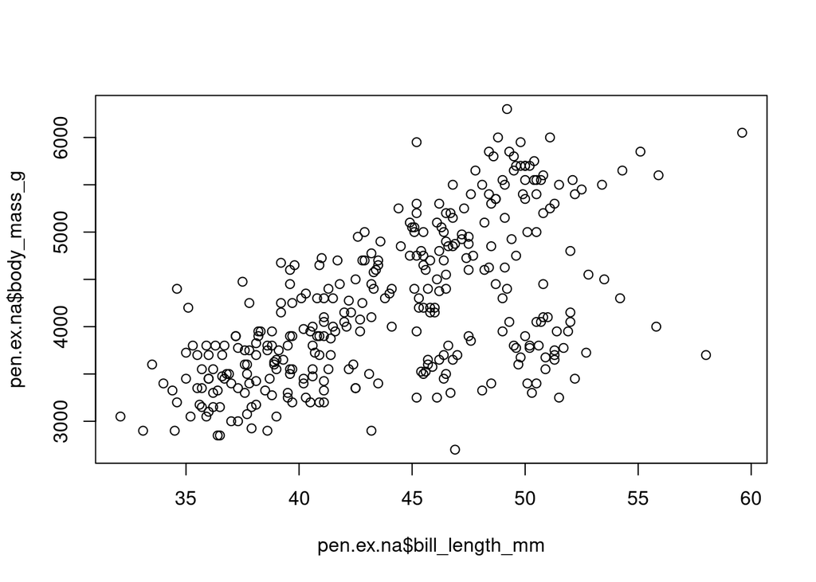

```r
plot(pen.ex.na$bill_length_mm, pen.ex.na$body_mass_g)
```

длина клюва зависит от массы тела?

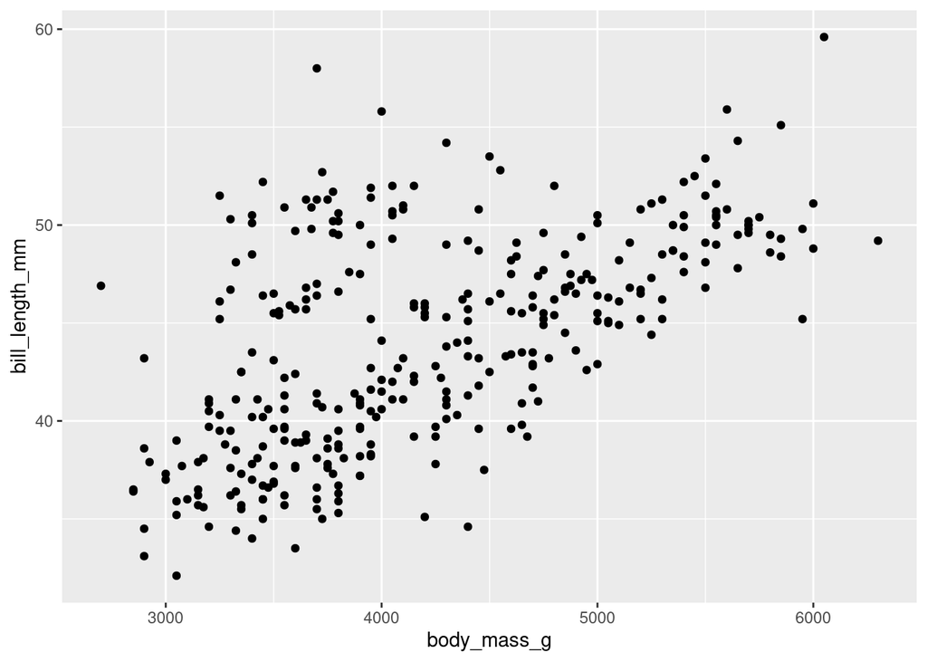

```r
ggplot(data = pen.ex.na) +
  geom_point(aes(x = body_mass_g,
                 y = bill_length_mm))
```

?stat_smooth

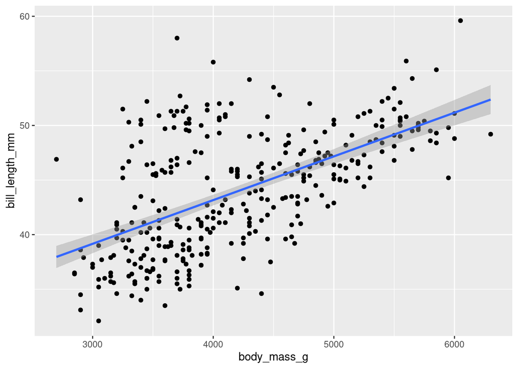

```r
pen.ex.na %>%
  ggplot(aes(x = body_mass_g,
             y = bill_length_mm)) +
  geom_point() +
  stat_smooth(method = "lm")
```

разные виды?

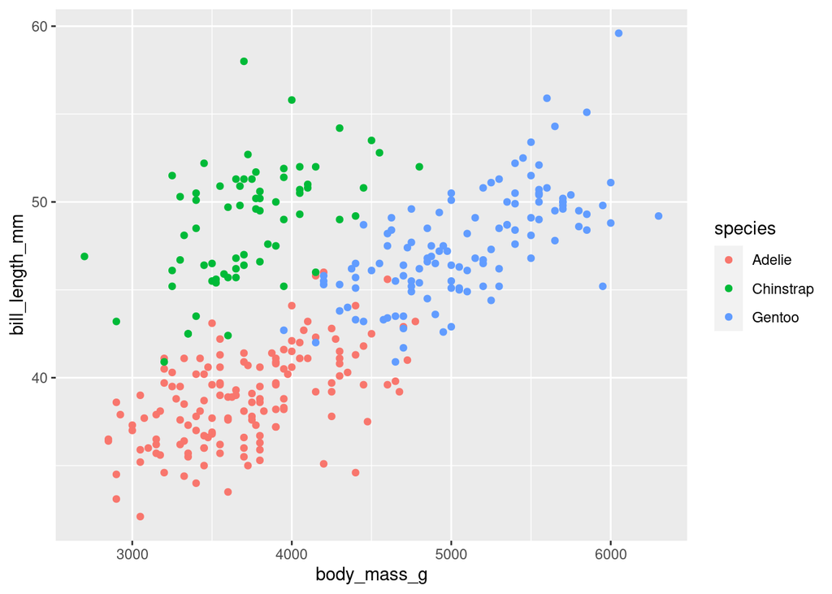

```r
pen.ex.na %>%
  ggplot() +
  geom_point(aes(x = body_mass_g,
                 y = bill_length_mm,
                 color = species))
```

### Боксплоты

смотрим вес у разных родов c разбиением на пол при помощи боксплотов

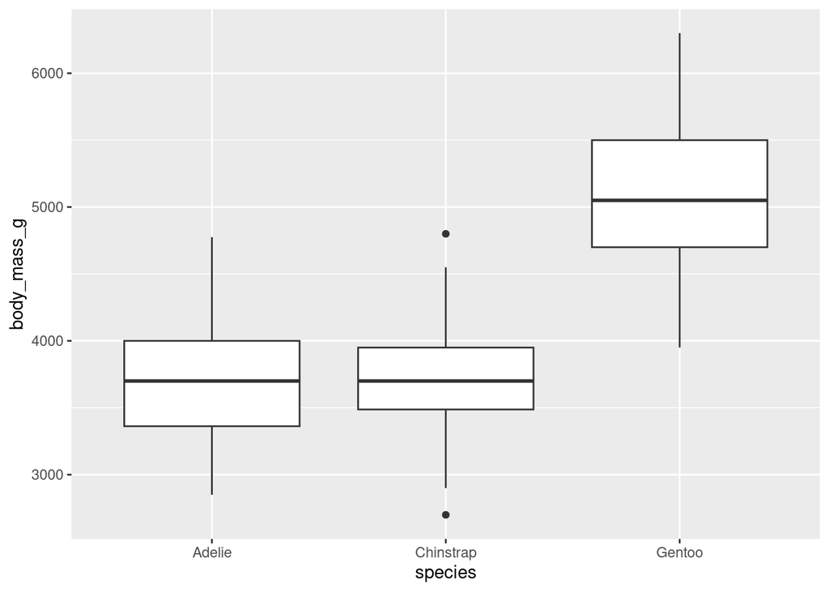

```r
pen.ex.na %>%
  ggplot() +
  geom_boxplot(aes(y = body_mass_g, x = species))
```

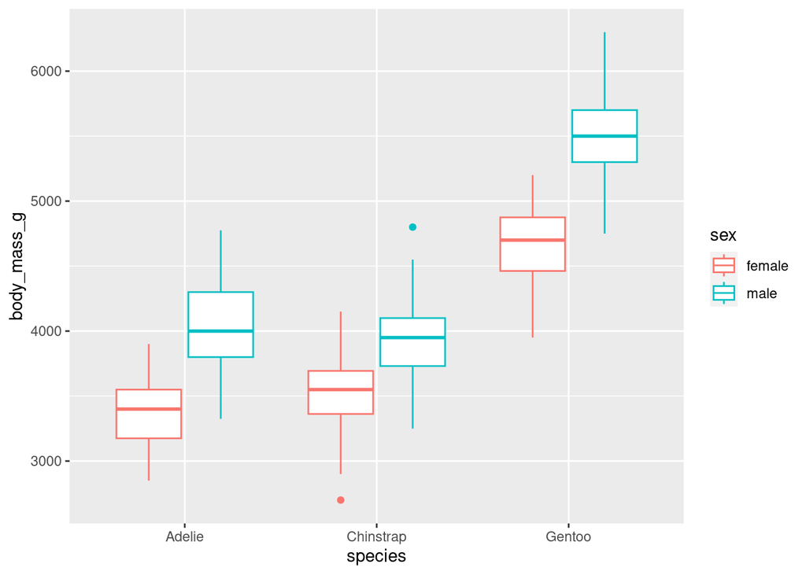

```r
pen.ex.na %>%
  ggplot() +
  geom_boxplot(aes(y = body_mass_g, x = species, color = sex))
```

у одних и тех же пингвинов на разных островах один и тот же вес

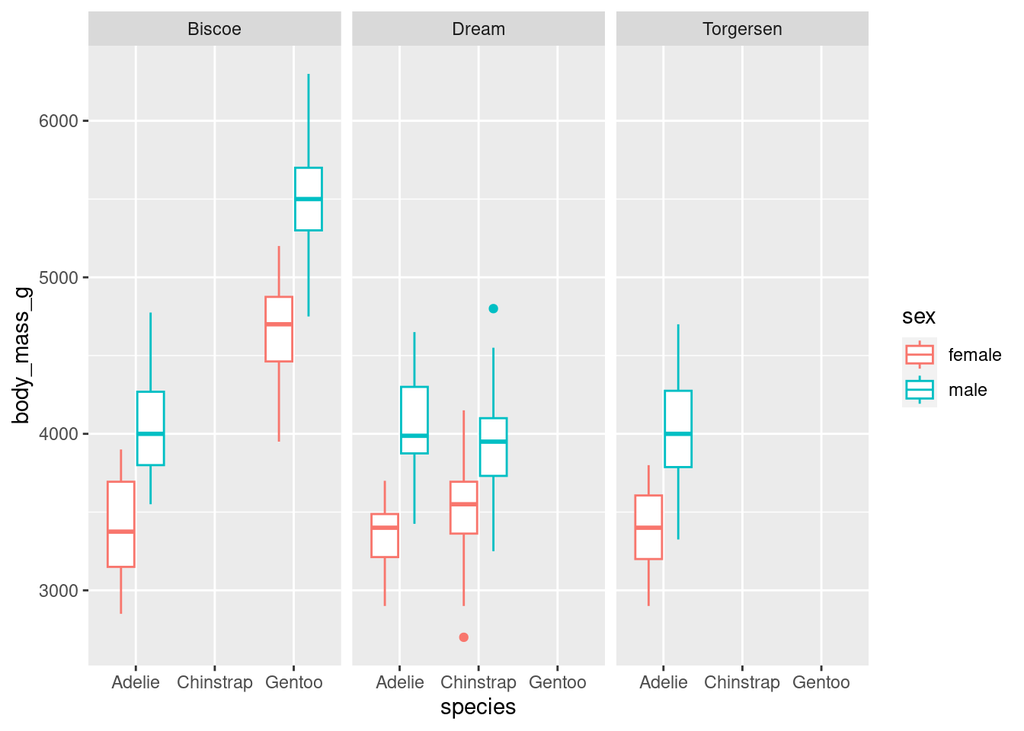

```r
pen.ex.na %>%
  ggplot(aes(y = body_mass_g, x = species, color = sex)) +
  geom_boxplot() +
  facet_wrap(~ island)
```

Более красивая версия картинки - пример показывает что можно наложить много слоёв

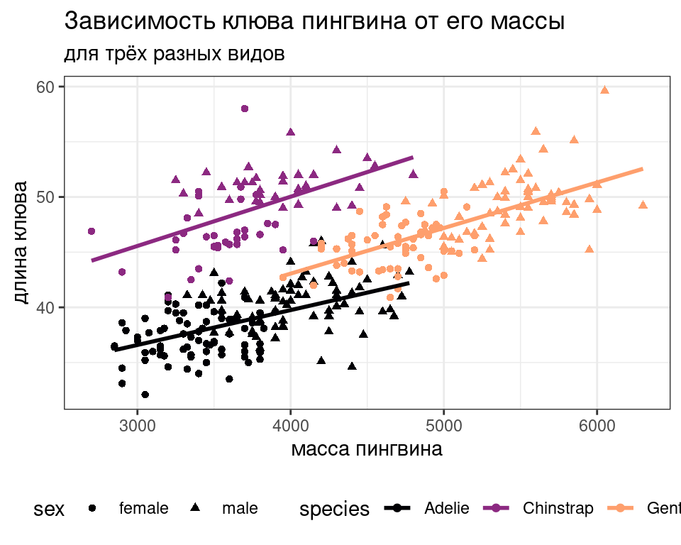

```r
pen.ex.na %>%
  ggplot(aes(x = body_mass_g,
             y = bill_length_mm)) +
  geom_point(aes(shape = sex,
                 color = species)) +
  geom_smooth(aes(fill=species,
                  color=species),
              method=lm,
              se=FALSE,
              ymin = 1) +
        scale_colour_viridis_d(option = "magma",
                       aesthetics = "color",
                       begin = 0,
                       end = 0.8) +
  xlab('масса пингвина') +
  ylab('длина клюва') +
  labs(title = 'Зависимость клюва пингвина от его массы',
       subtitle = 'для трёх разных видов') +
  theme_bw() +
  theme(legend.position='bottom')
```